# Code to reproduce tables and figures in *Simultaneous SNP selection and adjustment for population structure in high dimensional prediction models*. Bhatnagar et al. (2020). PLOS Genetics.

by Sahir Bhatnagar

2020-04-21

This `.Rmd` file contains the code to reproduce the tables and figures in the paper *Simultaneous SNP selection and adjustment for population structure in high dimensional prediction models*. Bhatnagar et al. (2020). PLOS Genetics.

# 1 How to compile this document

The easiest way to compile this document is to clone the https://github.com/sahirbhatnagar/ggmix repository or download the zip file https://github.com/sahirbhatnagar/ggmix/archive/master.zip. Open the file [`manuscript/bin/tables-figures.Rmd`](https://github.com/sahirbhatnagar/ggmix/blob/master/manuscript/bin/tables-figures.Rmd) in RStudio and click on the *Knit* button. If you don’t use RStudio, then from the `R` console enter `rmarkdown::render("manuscript/bin/tables-figures.Rmd")`. This assumes that you have installed both the `knitr` and `rmarkdown` packages, and are in the root of the `ggmix` folder.

The order in which the tables and figures appear follow that of the paper. The `R` scripts for each Table and Figure are in separate `R` files found in the [`manuscript/bin`](https://github.com/sahirbhatnagar/ggmix/tree/master/manuscript/bin) folder. This `.Rmd` document uses [code externalization](https://yihui.org/knitr/demo/externalization/).

# 2 Load Requires Packages

```r
if (!requireNamespace("pacman", quietly = TRUE)) {
  install.packages("pacman")
}

pacman::p_load(ggmix)
pacman::p_load(ComplexHeatmap) # for heatmaps
pacman::p_load(circlize) # for heatmaps
pacman::p_load(ggplot2) # for UKB imputed plot
pacman::p_load(latex2exp)
# pacman::p_load(truncnorm)
# pacman::p_load(lemon)
pacman::p_load(qwraps2) # used for simulation results table
pacman::p_load(kableExtra) # used for simulation results table
pacman::p_load(magrittr)
pacman::p_load(tidyr)
pacman::p_load_gh("thomasp85/patchwork")
pacman::p_load(simulator)
pacman::p_load(dplyr)
pacman::p_load(data.table)
pacman::p_load(here)
# pacman::p_load(roxygen2)
pacman::p_load(popkin)
pacman::p_load(bnpsd)
# pacman::p_load_gh("hrbrmstr/hrbrthemes")
# pacman::p_load(ggrepel)
# pacman::p_load(Cairo)
# pacman::p_load(extrafont)
# extrafont::loadfonts()
```

```r
cbbPalette <- c("#999999", "#E69F00", "#56B4E9", "#009E73", "#F0E442", "#0072B2", "#D55E00", "#CC79A7")
```

# 3 Figure 1

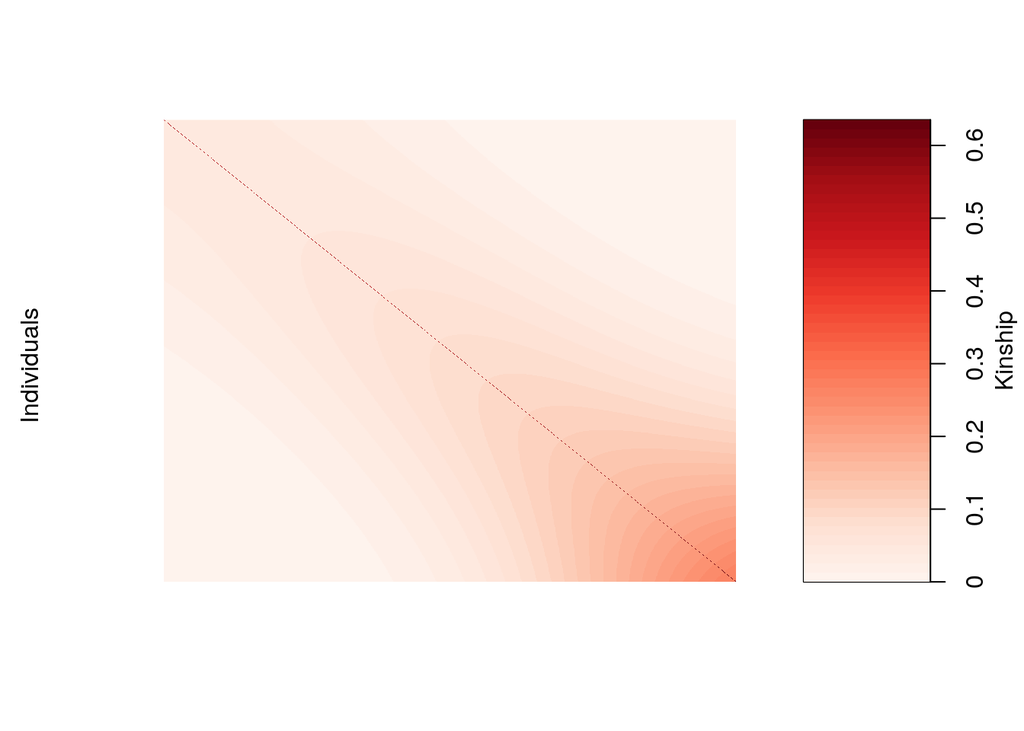

```r
dat <- lapply(
  list("1d"),
  function(i) {
    ggmix::gen_structured_model(
      n = 1200,
      p_design = 5000,
      p_kinship = 10000,
      geography = i,
      percent_causal = 0.01,
      percent_overlap = "100",
      k = 10, s = 0.5, Fst = 0.1,
      b0 = 0,
      eta = 0.1, sigma2 = 1,
      train_tune_test = c(0.99, .005, 0.005)
    )
  }
)

popkin::plot_popkin(kinship = list(dat[[1]]$kinship))
```

# 4 Figure 2

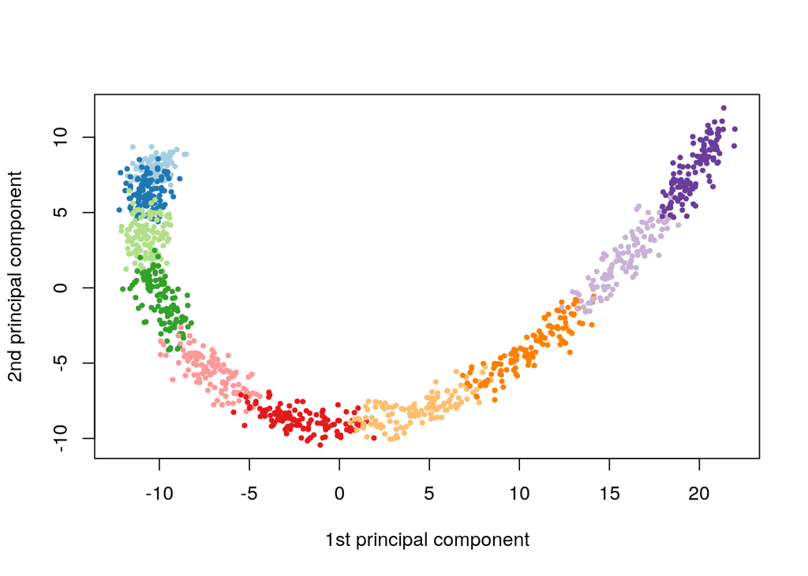

```r
xlabs <- "1st principal component"
ylabs <- "2nd principal component"

plot(dat[[1]]$PC[, 1], dat[[1]]$PC[, 2],
  pch = 19, col = rep(RColorBrewer::brewer.pal(10, "Paired"), each = table(dat[[1]]$subpops)[1]),
  xlab = xlabs, ylab = ylabs, cex = 0.5
)
```

# 5 Table 1

The simulation study results were run on a cluster using the simulator package. The simulator files can be found in the [`simulation`](https://github.com/sahirbhatnagar/ggmix/tree/master/simulation) folder:

- [`simulation/main.R`](https://raw.githubusercontent.com/sahirbhatnagar/ggmix/master/simulation/main.R) contains the main file which runs the simulation. This can be thought of as a master file which in turn calls the methods, model and eval functions
- [`simulation/model_functions.R`](https://raw.githubusercontent.com/sahirbhatnagar/ggmix/master/simulation/model_functions.R) contains the model functions, i.e., used to simulate the data
- [`simulation/method_functions.R`](https://raw.githubusercontent.com/sahirbhatnagar/ggmix/master/simulation/method_functions.R) contains the the individual methods which are applied on the simulated data
- [`simulation/eval_functions.R`](https://raw.githubusercontent.com/sahirbhatnagar/ggmix/master/simulation/eval_functions.R) contains the functions used to evaluate the different methods

```r
df <- readRDS(here::here("manuscript/data/simulation_results.rds"))

df <- df %>% separate(Model,
  into = c(
    "simnames", "b0", "beta_mean", "eta_p", "Fst", "geography", "k", "n",
    "pkinship", "ptest", "percentcausal",
    "percentoverlap", "s", "sigma2_p"
  ),
  sep = "/"
)

DT <- data.table::as.data.table(df, stringsAsFactors = FALSE)

DT[, p_overlap := case_when(
  percentoverlap == "percent_overlap_0" ~ "No causal SNPs in Kinship",
  percentoverlap == "percent_overlap_100" ~ "All causal SNPs in Kinship"
)]
DT[, p_causal := case_when(
  percentcausal == "percent_causal_0" ~ "Null model",
  percentcausal == "percent_causal_0.01" ~ "1% of SNPs are causal"
)]

DT[, p_causal := factor(p_causal, levels = c("Null model", "1% of SNPs are causal"))]


## --PATCH- # to keep code with as little change as possible, im renaming 1D to block
## because everything below is for "block". Even though, the may7th results are for 1D structure.
DT[geography == "geography_1d", structure := "block"]
DT[, structure := factor(structure, levels = c("block"))]
DT[, eta_p := case_when(
  eta_p == "eta_0.1" ~ "10% Heritability",
  eta_p == "eta_0.3" ~ "30% Heritability"
)]
DT[Method == "twostepYVCCV", Method := "twostep"]
DT[Method == "lassoCV", Method := "lasso"]
DT[Method == "ggmixHDBIC", Method := "ggmix"]
DT[, Method := factor(Method, levels = c("twostep", "lasso", "ggmix"))]
DT[Method == "twostep", errorvar := sigma2]
DT[Method == "twostep", tau := eta]
DT[Method == "twostep", eta := tau / (tau + sigma2)]

DT[, me2 := (1 / 1000) * me^2]
appender <- function(string) latex2exp::TeX(paste(string))

# theme_box <- theme_ipsum_rc(axis_title_just = "bt",axis_title_size = 16, axis = T, ticks = F, axis_col = "black") +
#   theme(legend.position = "bottom",title = element_text(size = 20),
#         axis.text.x = element_text(angle = 0, hjust = 0.5, size = 16),
#         axis.text.y = element_text(size = 16),
#         legend.text = element_text(size = 16), legend.title = element_text(size = 16),
#         strip.text = element_text(size = 18))
```

```r
DT$RMSE <- sqrt(DT$mse)

tt <- DT %>%
  group_by(Method, eta_p, p_overlap, p_causal) %>%
  summarise(
    RMSE = qwraps2::mean_sd(RMSE, denote_sd = "paren"),
    TPR = qwraps2::mean_sd(tprFPR5, denote_sd = "paren"),
    Heritability = qwraps2::mean_sd(eta, denote_sd = "paren"),
    Errorvar = qwraps2::mean_sd(errorvar, denote_sd = "paren"),
    Estimationerror = qwraps2::mean_sd(estimationerror, denote_sd = "paren"),
    Nactive = qwraps2::median_iqr(nactive, digits = 0)
  )

tt[tt$Method == "lasso", "Heritability"] <- "--"

pt <- tt %>%
  pivot_longer(
    cols = c("RMSE", "TPR", "Heritability", "Errorvar", "Estimationerror", "Nactive"),
    names_to = "metric"
  ) %>%
  unite(col = "type", p_causal, p_overlap, eta_p) %>%
  mutate(
    type = factor(type,
      levels = c(
        "Null model_No causal SNPs in Kinship_10% Heritability",
        "Null model_No causal SNPs in Kinship_30% Heritability",
        "Null model_All causal SNPs in Kinship_10% Heritability",
        "Null model_All causal SNPs in Kinship_30% Heritability",
        "1% of SNPs are causal_No causal SNPs in Kinship_10% Heritability",
        "1% of SNPs are causal_No causal SNPs in Kinship_30% Heritability",
        "1% of SNPs are causal_All causal SNPs in Kinship_10% Heritability",
        "1% of SNPs are causal_All causal SNPs in Kinship_30% Heritability"
      )
    ),
    metric = factor(metric,
      labels = c("TPR at FPR=5%", "Model Size", "RMSE", "Estimation Error", "Error Variance", "Heritability"),
      levels = c("TPR", "Nactive", "RMSE", "Estimationerror", "Errorvar", "Heritability")
    )
  ) %>%
  pivot_wider(id_cols = c("metric", "Method"), names_from = "type", values_from = "value") %>%
  arrange(metric, Method) %>%
  select(
    "metric", "Method", "Null model_No causal SNPs in Kinship_10% Heritability",
    "Null model_No causal SNPs in Kinship_30% Heritability",
    "Null model_All causal SNPs in Kinship_10% Heritability",
    "Null model_All causal SNPs in Kinship_30% Heritability",
    "1% of SNPs are causal_No causal SNPs in Kinship_10% Heritability",
    "1% of SNPs are causal_No causal SNPs in Kinship_30% Heritability",
    "1% of SNPs are causal_All causal SNPs in Kinship_10% Heritability",
    "1% of SNPs are causal_All causal SNPs in Kinship_30% Heritability"
  )
```

```r
kable(pt,
  booktabs = T, align = c("l", "l", "c", "c", "c", "c", "c", "c", "c", "c"),
  caption = c("Mean (standard deviation) from 200 simulations stratified by the number of causal SNPs (null, 1\\%), the overlap between causal SNPs and kinship matrix (no overlap, all causal SNPs in kinship), and true heritability (10\\%, 30\\%).
                  For all simulations, sample size is $n=1000$, the number of covariates is $p=5000$, and the number of SNPs used to estimate the kinship matrix is $k=10000$.
                  TPR at FPR=5\\% is the true positive rate at a fixed false positive rate of 5\\%.
                  Model Size ($|\\widehat{S}_{\\hat{\\lambda}}|$) is the number of selected variables in the training set using the high-dimensional BIC for \\texttt{ggmix} and 10-fold cross validation for \\texttt{lasso} and \\texttt{twostep}.
                  RMSE is the root mean squared error on the test set.
                  Estimation error is the squared distance between the estimated and true effect sizes.
                  Error variance ($\\sigma^2$) for \\texttt{twostep} is estimated from an intercept only LMM with a single random effect and is modeled explicitly in \\ggmix. For the \\texttt{lasso} we use $\\frac{1}{n - |\\widehat{S}_{\\hat{\\lambda}}|} ||\\bY - \\bX \\widehat{\\bbeta}_{\\hat{\\lambda}}||_2^2$~\\citep{reid2016study} as an estimator for $\\sigma^2$.
                  Heritability ($\\eta$) for \\texttt{twostep} is estimated as $\\sigma_g^2 / (\\sigma_g^2 + \\sigma_e^2)$ from an intercept only LMM with a single random effect where $\\sigma_g^2$ and $\\sigma_e^2$ are the variance components for the random effect and error term, respectively. $\\eta$ is explictly modeled in \\ggmix. There is no positive way to calculate $\\eta$ for the \\texttt{lasso} since we are using a PC adjustment."),
  col.names = c("Metric", "Method", rep(c("10%", "30%"), 4))
) %>%
  kable_styling(
    latex_options = "striped", full_width = TRUE,
    position = "center", font_size = 7, stripe_index = c(1:3, 7:9, 13:15)
  ) %>%
  add_header_above(c(" ", " ", "No overlap" = 2, "All causal SNPs\nin kinship" = 2, "No overlap" = 2, "All causal SNPs\nin kinship" = 2)) %>%
  add_header_above(c(" ", " ", "Null model" = 4, "1% Causal SNPs" = 4)) %>%
  column_spec(1, bold = T) %>%
  collapse_rows(columns = 1, latex_hline = "major", valign = "middle") %>%
  footnote(
    general = "Median (Inter-quartile range) is given for Model Size.",
    general_title = "Note:"
  )
```

Mean (standard deviation) from 200 simulations stratified by the number of causal SNPs (null, 1%), the overlap between causal SNPs and kinship matrix (no overlap, all causal SNPs in kinship), and true heritability (10%, 30%). For all simulations, sample size is $n=1000$, the number of covariates is $p=5000$, and the number of SNPs used to estimate the kinship matrix is $k=10000$. TPR at FPR=5% is the true positive rate at a fixed false positive rate of 5%. Model Size ($|\widehat{S}_{\hat{\lambda}}|$) is the number of selected variables in the training set using the high-dimensional BIC for and 10-fold cross validation for and . RMSE is the root mean squared error on the test set. Estimation error is the squared distance between the estimated and true effect sizes. Error variance ($\sigma^2$) for is estimated from an intercept only LMM with a single random effect and is modeled explicitly in . For the we use $\frac{1}{n - |\widehat{S}_{\hat{\lambda}}|} ||\textbf{Y}- \textbf{X}\widehat{\boldsymbol{\beta}}_{\hat{\lambda}}||_2^2$~ as an estimator for $\sigma^2$. Heritability ($\eta$) for is estimated as $\sigma_g^2 / (\sigma_g^2 + \sigma_e^2)$ from an intercept only LMM with a single random effect where $\sigma_g^2$ and $\sigma_e^2$ are the variance components for the random effect and error term, respectively. $\eta$ is explictly modeled in . There is no positive way to calculate $\eta$ for the since we are using a PC adjustment.

| Metric | Method | Null model No overlap 10% | Null model No overlap 30% | Null model All causal SNPs in kinship 10% | Null model All causal SNPs in kinship 30% | 1% Causal SNPs No overlap 10% | 1% Causal SNPs No overlap 30% | 1% Causal SNPs All causal SNPs in kinship 10% | 1% Causal SNPs All causal SNPs in kinship 30% |
| --- | --- | --- | --- | --- | --- | --- | --- | --- | --- |
| TPR at FPR=5% | twostep | 0.00 (0.00) | 0.00 (0.00) | 0.00 (0.00) | 0.00 (0.00) | 0.84 (0.05) | 0.84 (0.05) | 0.76 (0.09) | 0.77 (0.08) |
|  | lasso | 0.00 (0.00) | 0.00 (0.00) | 0.00 (0.00) | 0.00 (0.00) | 0.86 (0.05) | 0.85 (0.05) | 0.86 (0.05) | 0.86 (0.05) |
|  | ggmix | 0.00 (0.00) | 0.00 (0.00) | 0.00 (0.00) | 0.00 (0.00) | 0.86 (0.05) | 0.86 (0.05) | 0.85 (0.05) | 0.86 (0.05) |
| Model Size | twostep | 0 (0, 5) | 0 (0, 2) | 0 (0, 5) | 0 (0, 2) | 328 (289, 388) | 332 (287, 385) | 284 (250, 329) | 284 (253, 319) |
|  | lasso | 0 (0, 6) | 0 (0, 5) | 0 (0, 6) | 0 (0, 5) | 278 (246, 317) | 276 (245, 314) | 279 (252, 321) | 285 (244, 319) |
|  | ggmix | 0 (0, 0) | 0 (0, 0) | 0 (0, 0) | 0 (0, 0) | 43 (39, 49) | 43 (39, 48) | 44 (38, 49) | 43 (38, 48) |
| RMSE | twostep | 1.02 (0.07) | 1.02 (0.06) | 1.02 (0.07) | 1.02 (0.06) | 1.42 (0.10) | 1.41 (0.10) | 1.44 (0.33) | 1.40 (0.22) |
|  | lasso | 1.02 (0.06) | 1.02 (0.06) | 1.02 (0.06) | 1.02 (0.06) | 1.39 (0.09) | 1.38 (0.09) | 1.40 (0.08) | 1.38 (0.08) |
|  | ggmix | 1.00 (0.05) | 1.00 (0.05) | 1.00 (0.05) | 1.00 (0.05) | 1.22 (0.10) | 1.20 (0.10) | 1.23 (0.11) | 1.23 (0.12) |
| Estimation Error | twostep | 0.12 (0.22) | 0.09 (0.19) | 0.12 (0.22) | 0.09 (0.19) | 2.97 (0.60) | 2.92 (0.60) | 3.60 (5.41) | 3.21 (3.46) |
|  | lasso | 0.13 (0.21) | 0.12 (0.22) | 0.13 (0.21) | 0.12 (0.22) | 2.76 (0.46) | 2.69 (0.47) | 2.82 (0.48) | 2.75 (0.48) |
|  | ggmix | 0.00 (0.01) | 0.01 (0.02) | 0.00 (0.01) | 0.01 (0.02) | 2.11 (1.28) | 2.04 (1.22) | 2.21 (1.24) | 2.28 (1.34) |
| Error Variance | twostep | 0.87 (0.11) | 0.69 (0.15) | 0.87 (0.11) | 0.69 (0.15) | 14.23 (3.53) | 14.13 (3.52) | 1.42 (1.71) | 1.28 (1.66) |
|  | lasso | 0.98 (0.05) | 0.96 (0.05) | 0.98 (0.05) | 0.96 (0.05) | 1.04 (0.13) | 1.02 (0.13) | 1.03 (0.14) | 1.01 (0.14) |
|  | ggmix | 0.85 (0.18) | 0.64 (0.20) | 0.85 (0.18) | 0.64 (0.20) | 2.00 (0.49) | 1.86 (0.51) | 1.06 (0.46) | 0.83 (0.45) |
| Heritability | twostep | 0.13 (0.11) | 0.31 (0.15) | 0.13 (0.11) | 0.31 (0.15) | 0.26 (0.14) | 0.26 (0.14) | 0.92 (0.08) | 0.93 (0.08) |
|  | lasso | – | – | – | – | – | – | – | – |
|  | ggmix | 0.15 (0.18) | 0.37 (0.21) | 0.15 (0.18) | 0.37 (0.21) | 0.18 (0.16) | 0.23 (0.17) | 0.59 (0.20) | 0.68 (0.19) |

Note:  
Median (Inter-quartile range) is given for Model Size.

# 6 Figure 3

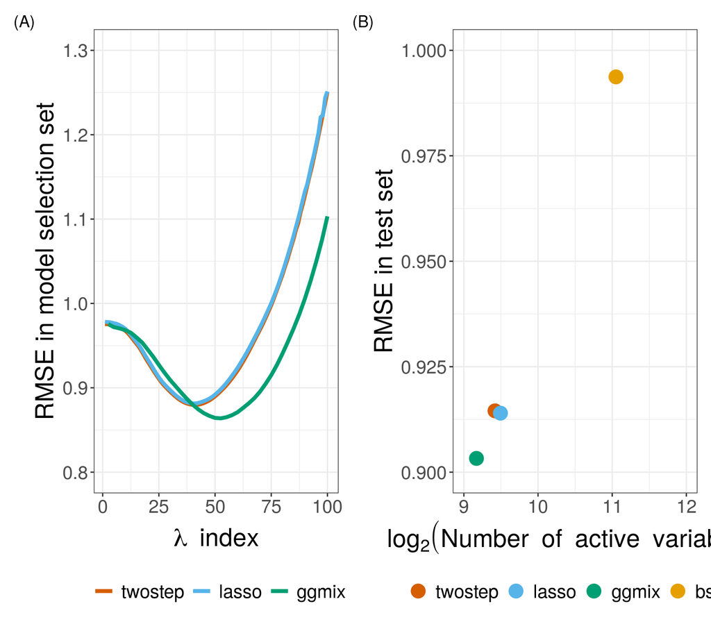

```r
root <- here::here("manuscript/data/")
load(paste0(root, "UKB-plot-data.RData"))
p1 <- ggplot(valstats, aes(x = index, y = RMSE, color = method)) +
  geom_line(size = 1.5) +
  theme_bw() +
  scale_color_manual(values = cbbPalette[c(7, 3, 4)]) +
  theme(
    legend.position = "bottom", axis.text = element_text(size = 15),
    axis.title = element_text(size = 20),
    legend.text = element_text(size = 15)
  ) +
  labs(color = "", x = expression(lambda ~ index), y = "RMSE in model selection set") +
  ylim(0.8, 1.3)

p2 <- ggplot(teststats, aes(x = log2(coef), y = RMSE, color = method)) +
  ylim(0.9, 1) +
  xlim(9, 12) +
  geom_point(size = 5) +
  xlab(expression(log[2](Number ~ of ~ active ~ variables))) +
  ylab("RMSE in test set") +
  labs(color = "") +
  theme_bw() +
  theme(
    legend.position = "bottom",
    axis.text = element_text(size = 15),
    axis.title = element_text(size = 20),
    legend.text = element_text(size = 15),
    axis.text.x = element_text(angle = 0, hjust = 0.5, vjust = 1)
  ) +
  scale_color_manual(values = cbbPalette[c(7, 3, 4, 2)])

p1 + p2 + plot_annotation(tag_levels = "A", tag_prefix = "(", tag_suffix = ")")
```

# 7 Table 2

```r
root <- here::here("manuscript/data/")
load(paste0(root, "GAW20-RMSE-Nactive.RData"))

knitr::kable(RMSEACTIVE)
```

| meanRMSE | sdRMSE | meanACTIVE | sdACTIVE | upper90ACTIVE | upper95ACTIVE | Method |
| --- | --- | --- | --- | --- | --- | --- |
| 0.3604 | 0.0242 | 1 | 26.86 | 10.9 | 21.0 | twostep |
| 0.3105 | 0.0199 | 1 | 29.72 | 15.0 | 33.2 | lasso |
| 0.3146 | 0.0210 | 1 | 8.16 | 12.0 | 21.0 | ggmix |

# 8 Figure 4

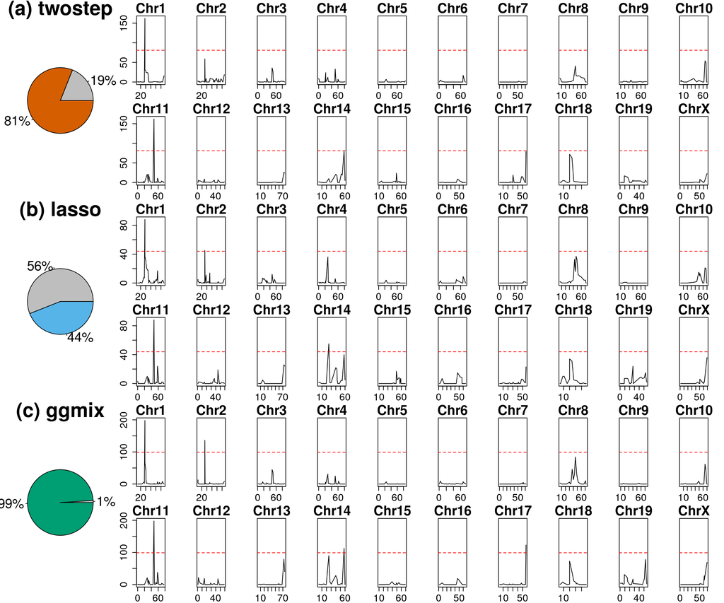

```r
root <- here::here("manuscript/data/")
load(paste0(root, "Mice-200Bootstrap.RData"))
load(paste0(root, "mice.RData"))


ggmixpie <- c(ggmixfail, 200 - ggmixfail)
ggmixlab <- c("Failure", "Success")

lassopie <- c(lassofail, 200 - lassofail)
lassolab <- c("Failure", "Success")

twosteppie <- c(twostepfail, 200 - twostepfail)
twosteplab <- c("Failure", "Success")

# Twostep

layout(matrix(c(1, 1:11, 1, 1, 12:21, 22, 22:32, 22, 22, 33:42, 43, 43:53, 43, 43, 54:63), 6, 12, byrow = TRUE))
par(mar = c(2, 2, 2, 2))

plotGenome <- genotype[, 1:3]
plotGenome$count <- NA

pie(twosteppie, labels = paste0(prop.table(twosteppie) * 100, "%"),
    cex = 2, main = "(a) twostep", cex.main = 3,
    col = c("grey", cbbPalette[7]), radius = 0.8)

for (j in 1:nrow(plotGenome)) {
  plotGenome$count[j] <- length(which(twostepCoef == plotGenome$marker[j]))
}

for (chr in 1:20) {
  subdat <- plotGenome[plotGenome$chr == chr, ]
  if (chr != 20) {
    if (!chr %in% c(1, 11)) {
      plot(subdat$cM, subdat$count, type = "l", xlab = NA, ylab = NA,
           ylim = c(0, 200 - twostepfail), main = paste0("Chr", chr),
           cex.main = 2, yaxt = "n", cex.axis = 1.5)
      abline(h = (200 - twostepfail) / 2, lty = 2, col = "red")
    }
    else {
      plot(subdat$cM, subdat$count, type = "l", xlab = NA, ylab = NA,
           ylim = c(0, 200 - twostepfail), main = paste0("Chr", chr),
           cex.main = 2, cex.axis = 1.5)
      abline(h = (200 - twostepfail) / 2, lty = 2, col = "red")
    }
  }
  else {
    plot(subdat$cM, subdat$count, type = "l", xlab = NA, ylab = NA,
         ylim = c(0, 200 - twostepfail), main = "ChrX", cex.main = 2,
         yaxt = "n", cex.axis = 1.5)
    abline(h = (200 - twostepfail) / 2, lty = 2, col = "red")
  }
}


# LASSO

plotGenome <- genotype[, 1:3]
plotGenome$count <- NA

pie(lassopie, labels = paste0(prop.table(lassopie) * 100, "%"), cex = 2,
    main = "(b) lasso", cex.main = 3, col = c("grey", cbbPalette[3]),
    radius = 0.8)

for (j in 1:nrow(plotGenome)) {
  plotGenome$count[j] <- length(which(lassoCoef == plotGenome$marker[j]))
}

for (chr in 1:20) {
  subdat <- plotGenome[plotGenome$chr == chr, ]
  if (chr != 20) {
    if (!chr %in% c(1, 11)) {
      plot(subdat$cM, subdat$count, type = "l", xlab = NA, ylab = NA,
           ylim = c(0, 200 - lassofail), main = paste0("Chr", chr),
           cex.main = 2, yaxt = "n", cex.axis = 1.5)
      abline(h = (200 - lassofail) / 2, lty = 2, col = "red")
    }
    else {
      plot(subdat$cM, subdat$count, type = "l", xlab = NA, ylab = NA,
           ylim = c(0, 200 - lassofail), main = paste0("Chr", chr),
           cex.main = 2, cex.axis = 1.5)
      abline(h = (200 - lassofail) / 2, lty = 2, col = "red")
    }
  }
  else {
    plot(subdat$cM, subdat$count, type = "l", xlab = NA, ylab = NA,
         ylim = c(0, 200 - lassofail), main = "ChrX", cex.main = 2,
         yaxt = "n", cex.axis = 1.5)
    abline(h = (200 - lassofail) / 2, lty = 2, col = "red")
  }
}

# GGMIX

plotGenome <- genotype[, 1:3]
plotGenome$count <- NA

pie(ggmixpie, labels = paste0(prop.table(ggmixpie) * 100, "%"), cex = 2,
    main = "(c) ggmix", cex.main = 3, col = c("grey", cbbPalette[4]),
    radius = 0.8)

for (j in 1:nrow(plotGenome)) {
  plotGenome$count[j] <- length(which(ggmixCoef == plotGenome$marker[j]))
}

for (chr in 1:20) {
  subdat <- plotGenome[plotGenome$chr == chr, ]
  if (chr != 20) {
    if (!chr %in% c(1, 11)) {
      plot(subdat$cM, subdat$count, type = "l", xlab = NA, ylab = NA,
           ylim = c(0, 200 - ggmixfail), main = paste0("Chr", chr),
           cex.main = 2, yaxt = "n", cex.axis = 1.5)
      abline(h = (200 - ggmixfail) / 2, lty = 2, col = "red")
    }
    else {
      plot(subdat$cM, subdat$count, type = "l", xlab = NA, ylab = NA,
           ylim = c(0, 200 - ggmixfail), main = paste0("Chr", chr),
           cex.main = 2, cex.axis = 1.5)
      abline(h = (200 - ggmixfail) / 2, lty = 2, col = "red")
    }
  }
  else {
    plot(subdat$cM, subdat$count, type = "l", xlab = NA, ylab = NA,
         ylim = c(0, 200 - ggmixfail), main = "ChrX", cex.main = 2,
         yaxt = "n", cex.axis = 1.5)
    abline(h = (200 - ggmixfail) / 2, lty = 2, col = "red")
  }
}
```

# 9 S1 Figure

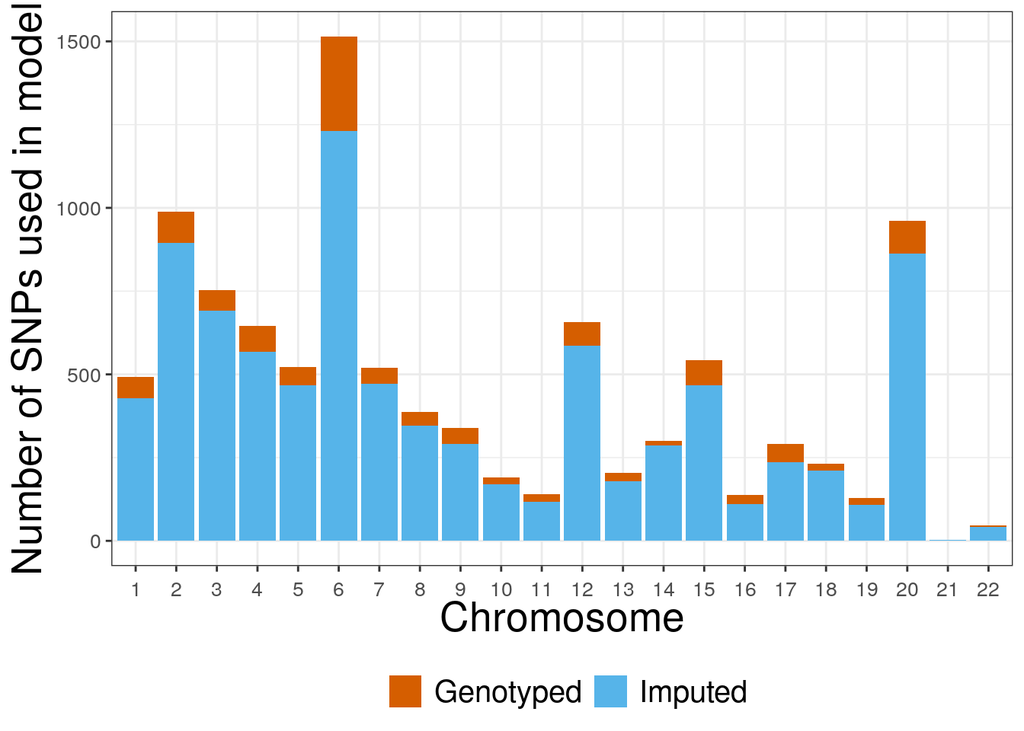

```r
ukb_df <- data.frame(
  Chromosome = factor(1:22),
  freq = c(493, 989, 754, 645, 522, 1515, 520, 388, 338, 190, 141, 658, 204, 300, 543, 138, 292, 231, 128, 962, 3, 46),
  genotyped = c(65, 95, 62, 78, 55, 284, 48, 42, 47, 20, 24, 71, 24, 14, 77, 27, 56, 20, 20, 99, 1, 4)
)


ukb_long <- do.call(rbind, lapply(1:nrow(ukb_df), function(i) {
  data.frame(
    Chromosome = rep(ukb_df$Chromosome[i], each = ukb_df$freq[i]),
    Genotyped = c(rep("Genotyped", ukb_df$genotyped[i]), rep("Imputed", ukb_df$freq[i] - ukb_df$genotyped[i]))
  )
}))

ggplot(ukb_long, aes(x = Chromosome, fill = Genotyped)) +
  geom_bar() +
  ylab("Number of SNPs used in model") +
  labs(color = "") +
  theme_bw() +
  theme(
    legend.position = "bottom",
    legend.title = element_blank(),
    axis.text = element_text(size = 10),
    axis.title = element_text(size = 20),
    legend.text = element_text(size = 15),
    axis.text.x = element_text(angle = 0, hjust = 0.5, vjust = 0)
  ) +
  scale_fill_manual(values = cbbPalette[c(7, 3)])
```

# 10 S2 Figure

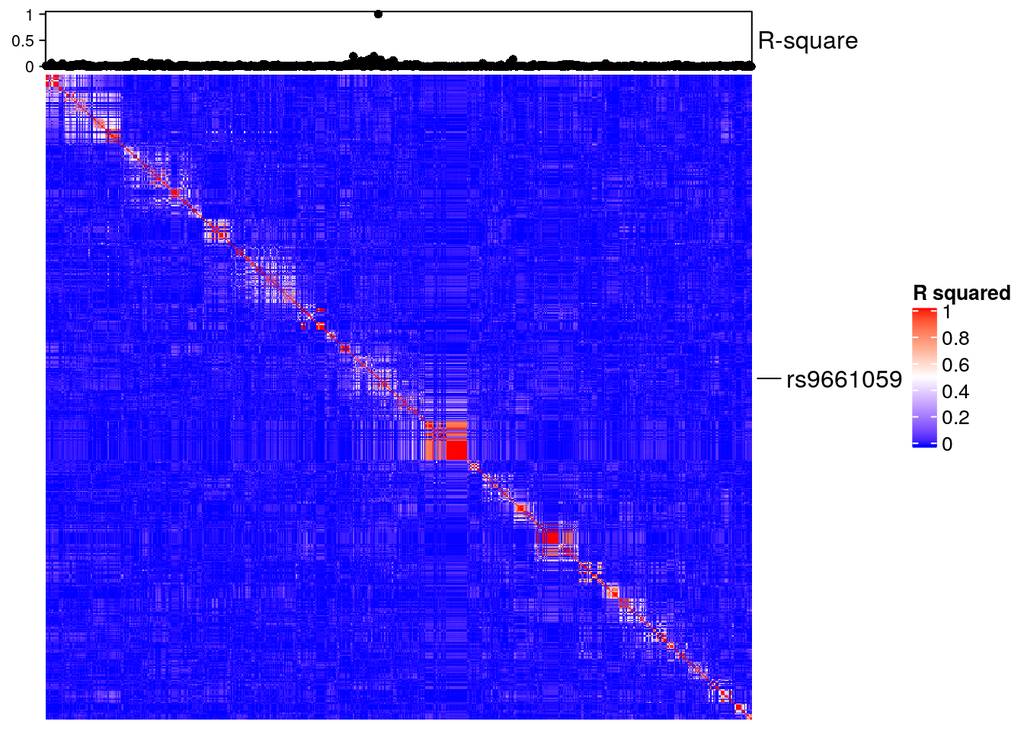

```r
root <- here::here("manuscript/data/")
load(paste0(root, "Chr1AroundCausal.ld.RData"))
Gaw <- as.matrix(Gaw)
col_fun <- colorRamp2(c(0, 0.5, 1), c("blue", "white", "red"))


ha <- rowAnnotation(foo = anno_mark(at = 309, labels = "rs9661059"))
har2 <- HeatmapAnnotation(`R-square` = anno_points(as.vector(Gaw[309, ])))
ComplexHeatmap::Heatmap(Gaw,
  cluster_columns = F, cluster_rows = F,
  show_row_names = F, show_column_names = F,
  right_annotation = ha, top_annotation = har2,
  col = col_fun, name = "R squared"
)
```

# 11 S3 Figure

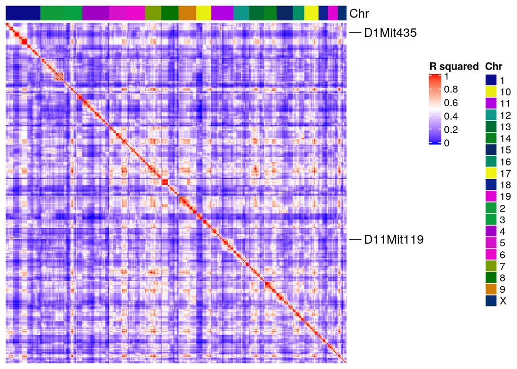

```r
root <- here::here("manuscript/data/")
load(paste0(root, "markerCorrelationBCG.RData"))
col_fun <- colorRamp2(c(0, 0.5, 1), c("blue", "white", "red"))

chrname <- substr(rownames(corMice), 1, 4)
chrcount <- c(63, 43, 33, 49, 31, 34, 29, 32, 32, 27, 41, 28, 27, 23, 29, 21, 26, 17, 18, 16)
chrlabel <- c()
for (i in 1:20) {
  chrlabel <- c(chrlabel, rep(i, chrcount[i]))
}
chrlabel[chrlabel == 20] <- "X"

ha <- rowAnnotation(foo = anno_mark(at = c(which(rownames(corMice) == "D1Mit435"),
                                           which(rownames(corMice) == "D11Mit119")),
                                    labels = c("D1Mit435", "D11Mit119")))
hachr <- columnAnnotation(Chr = chrlabel)

ComplexHeatmap::Heatmap(corMice, cluster_columns = F,
                        cluster_rows = F, show_row_names = F,
                        show_column_names = F, right_annotation = ha,
                        top_annotation = hachr, col = col_fun, name = "R squared")
```

# 12 File and Session Information

- File creation date: 2020-04-21
  - R version 3.6.2 (2019-12-12)
  - R version (short form): 3.6.2